# Desafío Spike Septiembre 2020

Lautaro Cantar

01/Oct/2020

```r
# Cargando paquetes a utilizar
library(tidyverse)  # Manipulación y transformación de datos
library(skimr)      # Tablas resumen sencillas
library(lubridate)  # Manejo de fechas
```

# Preguntas

## 1. Costos marginales

- Carga el archivo `costo_marginal_real.csv`. Estos son los costos marginales reales observados.
- Carga el archivo `costo_marginal_programado.csv`. Estos son los costos marginales previstos por el sistema.
- Haz un merge del costos marginal real con el costo marginal programado a nivel de barra (*Ayuda: la columna de join no se llama igual en ambas bases! Los datos venían así del SIC* ). Llama a esta nueva base `costo_marginal`.
- Realiza un análisis exploratorio de la base resultante. ¿Qué puedes decir de las distintas variables? ¿Cómo distribuyen? En particular analiza las barras (barra_mnemotecnico). ¿Para cuántas barras se programa el costo? ¿Qué porcentaje es del total de barras que puedes observar en la base?

### Resolución

```r
# Cargando los datasets
costo_marginal_real <- read_csv("costo_marginal_real.csv")
costo_marginal_programado <- read_csv("costo_marginal_programado.csv")
```

Antes de realizar el merge, se realizó una exploración de los datos de ambos archivos para evaluar su integridad y qué pasos eran necesarios tomar para su eventual limpieza. De tan exploración surge que los datos pertenecen todos al primer semestre del año 2019, que hay registros para las 24 horas del día salvo para la fecha *2019-04-06* que tiene registros para la hora 25.

Para el archivo `costo_marginal_real` en particular, se elimina la variable `barra_referencia_mnemotecnico` ya que tiene un único valor *“BA02T002SE032T002”* a lo largo de todo el archivo y, por lo tanto, no suma valor.

Para el archivo `costo_marginal_programado` se identificaron 4283 observaciones duplicadas en todas sus variables y fueron eliminadas. De las observaciones restantes, valores 183946 datos duplicados con los mismos valores de las siguientes variables: `mnemotecnico_barra`, `fecha` y `hora`. Por lo tanto para las observaciones con más de una observación con iguales variables, la variable `costo` es el promedio del costo de esas observaciones.

Por último se realiza el merge por las variables `mnemotecnico_barra`, `fecha` y `hora`.

```r
# Limpiando los datos
costo_marginal_real <- costo_marginal_real %>%
  select(-barra_referencia_mnemotecnico) %>%  # Elimino esta variable porque es un valor único
  rename(costo_en_dolares_real = costo_en_dolares)

costo_marginal_programado <- costo_marginal_programado %>%
  distinct() %>%
  group_by(mnemotecnico_barra, nombre_barra, fecha, hora) %>%
  summarise(costo_programado = mean(costo))

# Realizando el merge
costo_marginal <- costo_marginal_real %>%
  left_join(costo_marginal_programado,
            by = c("barra_mnemotecnico" = "mnemotecnico_barra",
                   "fecha" = "fecha",
                   "hora" = "hora"))
```

Para realizar el análisis exploratorio de la base resultante vamos a utilizar la variable `skimr::skim()` que nos brinda una gran cantidad de estadísticas descriptivas.

Cuando se analizan las variables del tipo *“character”* vemos que existen 1020 barras únicas (`barra_mnemotecnico`) pero tan solo se calcula el costo para el 21% de esas barras. Este dato se puede ver que la variable `nombre_barra` que proviene del dataset `costo_marginal_programado` tiene 3409022 variables NA. Luego se puede ver que siguen habiendo datos para el primer semestre de 2019 (181 días en total).

Respecto a las variables numéricas, vemos que la variable `costo_programado` (costo marginal programado) también tiene tan solo el 21% de las observaciones completas. Un dato curioso es que dicha variable tiene valores negativos. Al explorar un poco más los datos, hay 279 valores que son negativos y están concentrados en 4 barras en particular: *“BA01G132SE001G132”*, *“BA01T002SE056T002”*, *“BA74T005SE278T005”* y *“BA94G216SE031G216”*. Estos datos provienen así del archivo original.

```r
skim(costo_marginal)
```

Data summary

| Name | costo_marginal |
| --- | --- |
| Number of rows | 4309951 |
| Number of columns | 8 |
| _______________________ |  |
| Column type frequency: |  |
| character | 3 |
| Date | 1 |
| numeric | 4 |
| ________________________ |  |
| Group variables | None |

**Variable type: character**

| skim_variable | n_missing | complete_rate | min | max | empty | n_unique | whitespace |
| --- | --- | --- | --- | --- | --- | --- | --- |
| barra_mnemotecnico | 0 | 1.00 | 17 | 17 | 0 | 1020 | 0 |
| nombre | 0 | 1.00 | 15 | 60 | 0 | 1020 | 0 |
| nombre_barra | 3409022 | 0.21 | 15 | 47 | 0 | 220 | 0 |

**Variable type: Date**

| skim_variable | n_missing | complete_rate | min | max | median | n_unique |
| --- | --- | --- | --- | --- | --- | --- |
| fecha | 0 | 1 | 2019-01-01 | 2019-06-30 | 2019-04-01 | 181 |

**Variable type: numeric**

| skim_variable | n_missing | complete_rate | mean | sd | p0 | p25 | p50 | p75 | p100 | hist |
| --- | --- | --- | --- | --- | --- | --- | --- | --- | --- | --- |
| hora | 0 | 1.00 | 12.50 | 6.92 | 1.00 | 7.00 | 13.00 | 19.00 | 25.00 | ▇▇▇▇▆ |
| costo_en_dolares_real | 0 | 1.00 | 63.71 | 28.01 | 0.00 | 50.65 | 56.09 | 65.90 | 1109.97 | ▇▁▁▁▁ |
| costo_en_pesos | 0 | 1.00 | 43.00 | 18.65 | 0.00 | 34.11 | 37.99 | 44.72 | 734.36 | ▇▁▁▁▁ |
| costo_programado | 3409022 | 0.21 | 61.89 | 23.85 | -12.11 | 49.98 | 55.06 | 64.15 | 610.60 | ▇▁▁▁▁ |

## 2. Construcción de variables

Construye las siguientes variables para la base que creaste en el punto anterior:

- `desviación`: la diferencia entre el costo real y el costo programado
- `desviación_pct`: la misma desviación, pero en porcentaje
- `desviacion_cat`: una variable categórica que vale 1 si la desviación_pct absoluta es mayor a 15% (esto es, si es menor a -15% o mayor a 15%)

Describe la variable `desviacion_cat`. Qué puedes observar? Cambia a través del tiempo?

### Resolución

Para el cálculo de la variable `desviación_pct` se toma como base la variable `costo_programado`

```r
costo_marginal <- costo_marginal %>%
  mutate(desviacion = costo_en_dolares_real - costo_programado,
         desviación_pct = desviacion/costo_programado,
         desviacion_cat = case_when(desviación_pct > 0.15 | desviación_pct < -0.15 ~ 1))
```

```r
vble_desviacion_cat <- costo_marginal %>%
  filter(!is.na(desviación_pct)) %>%
  mutate(mes = fecha %>% month(),
         desviacion_cat = case_when(desviacion_cat == 1 ~ 1,
                                    TRUE ~ 0)) %>%
  group_by(mes, desviacion_cat) %>%
  tally()
```

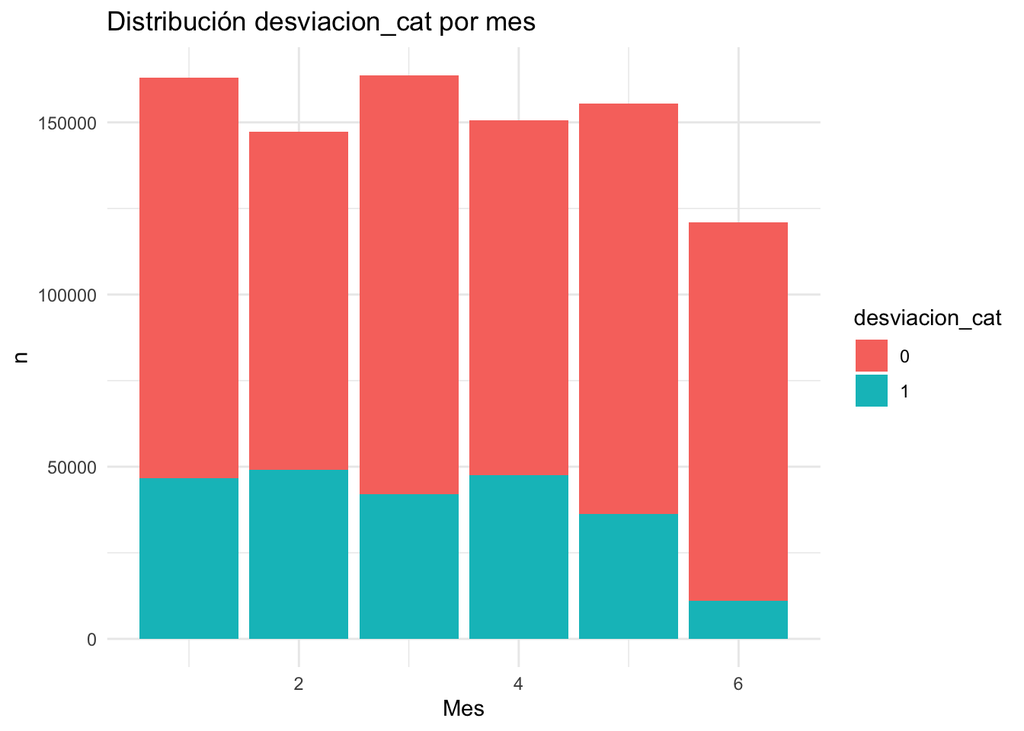

```r
ggplot() +
  geom_col(data = vble_desviacion_cat,
           aes(x = mes, y = n, fill = factor(desviacion_cat))) +
  labs(title = "Distribución desviacion_cat por mes",
       fill = "desviacion_cat",
       x = "Mes") +
  theme_minimal()
```

## 3. Visualización de datos

Qué puedes concluir de estos plots?

Además, identifica la barra que tiene cmg_real= 0 durante todos los días y elimínala de tu dataset.

### Resolucion

```r
time_plot_costo_barra <- function(codigo_barra,
                                  fecha_inicial,
                                  fecha_final){

  d <- costo_marginal %>%
    filter(barra_mnemotecnico == codigo_barra) %>% # codigo_barra
    filter(fecha >= fecha_inicial,
           fecha <= fecha_final) %>%
    mutate(fecha = paste(fecha, paste0(hora, ":00:00")),
           fecha = fecha %>% ymd_hms()) %>%
    select(barra_mnemotecnico, fecha, costo_en_dolares_real, costo_programado) %>%
    pivot_longer(!c(barra_mnemotecnico,fecha))

  ggplot() +
    geom_line(data = d,
              aes(x = fecha, y = value, color = name),
              size = 0.8) +
    labs(title = "Evolución Costo Marginal Real y Costo Marginal Programado",
         subtitle = paste("Barra:", codigo_barra),
         color = "Variable",
         x = "Fecha",
         y = "") +
    theme_minimal()

}
```

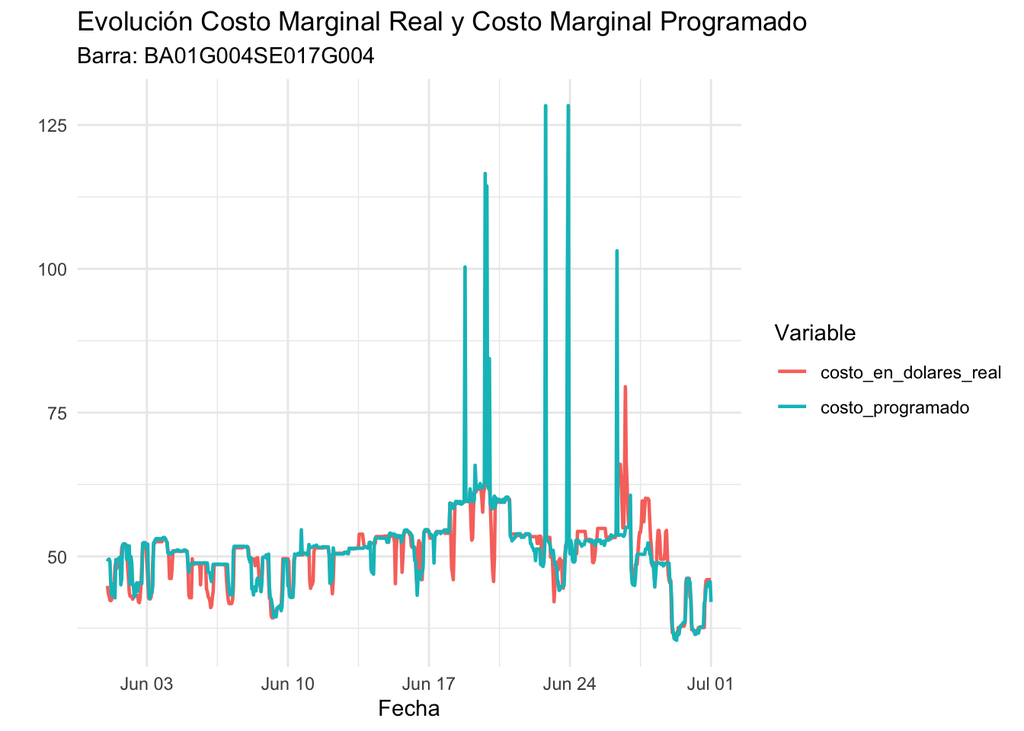

```r
time_plot_costo_barra("BA01G004SE017G004", "2019-06-01", "2019-06-30")
```

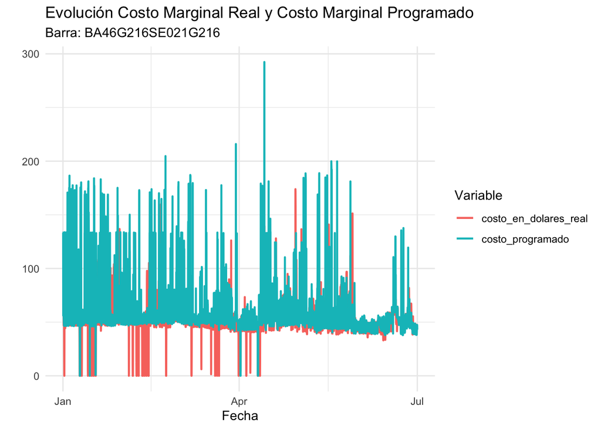

```r
time_plot_costo_barra("BA46G216SE021G216", "2019-01-01", "2019-06-30")
```

Eliminando las barras cuyos Costo Marginal es cero en todas sus filas.

```r
dat_soporte <- costo_marginal %>%
  group_by(barra_mnemotecnico) %>%
  summarise(suma_costo_mg_real_dolares = sum(costo_en_dolares_real),
            n = n()) %>%
  filter(suma_costo_mg_real_dolares == 0)

costo_marginal <- costo_marginal %>%
  filter(!barra_mnemotecnico %in% dat_soporte$barra_mnemotecnico)
```

## 4. Base para los modelos

Carga la base `base_para_predicción.csv`. Esta será la base principal para las siguientes preguntas.

```r
# Cargando los datasets
base_para_prediccion <- read_csv("base_para_prediccion.csv")
```

- En rasgos generales, ¿Qué puedes decir de los datos? (dimensiones, tipo de datos, variables categóricas, variables numéricas, fechas).

El dataset esta compuesto por 112779 observaciones y 15 variables. El dataset se ve de la siguiente forma:

```r
base_para_prediccion %>% head() %>% knitr::kable()
```

| nemotecnico_se | fecha | hora | gen_eolica_total_mwh | gen_geotermica_total_mwh | gen_hidraulica_total_mwh | gen_solar_total_mwh | gen_termica_total_mwh | cmg_real | cmg_prog | cmg_desv | cmg_desv_pct | n_barras | demanda_mwh | cap_inst_mw |
| --- | --- | --- | --- | --- | --- | --- | --- | --- | --- | --- | --- | --- | --- | --- |
| SE031G216 | 2019-01-04 00:00:00 UTC | 1 | NA | NA | NA | NA | 0 | 56.2 | 55.62785 | 0.57 | 1.02 | 2 | 1210767 | 13.20785 |
| SE031G216 | 2019-01-04 00:00:00 UTC | 2 | NA | NA | NA | NA | 0 | 56.2 | 55.37664 | 0.82 | 1.48 | 2 | 113232 | 13.20785 |
| SE031G216 | 2019-01-04 00:00:00 UTC | 3 | NA | NA | NA | NA | 0 | 56.2 | 59.53189 | -3.33 | -5.59 | 2 | 1089415 | 13.20785 |
| SE031G216 | 2019-01-04 00:00:00 UTC | 4 | NA | NA | NA | NA | 0 | 56.2 | 174.37892 | -118.18 | -67.77 | 2 | 1096867 | 13.20785 |
| SE031G216 | 2019-01-04 00:00:00 UTC | 5 | NA | NA | NA | NA | 0 | 56.2 | 172.82031 | -116.62 | -67.48 | 2 | 1071851 | 13.20785 |
| SE031G216 | 2019-01-04 00:00:00 UTC | 6 | NA | NA | NA | NA | 0 | 56.2 | 172.82031 | -116.62 | -67.48 | 2 | 1038729 | 13.20785 |

```r
skim(base_para_prediccion)
```

Data summary

| Name | base_para_prediccion |
| --- | --- |
| Number of rows | 112779 |
| Number of columns | 15 |
| _______________________ |  |
| Column type frequency: |  |
| character | 2 |
| logical | 3 |
| numeric | 10 |
| ________________________ |  |
| Group variables | None |

**Variable type: character**

| skim_variable | n_missing | complete_rate | min | max | empty | n_unique | whitespace |
| --- | --- | --- | --- | --- | --- | --- | --- |
| nemotecnico_se | 0 | 1 | 9 | 9 | 0 | 29 | 0 |
| fecha | 0 | 1 | 23 | 23 | 0 | 181 | 0 |

**Variable type: logical**

| skim_variable | n_missing | complete_rate | mean | count |
| --- | --- | --- | --- | --- |
| gen_eolica_total_mwh | 112779 | 0.00 | NaN | : |
| gen_geotermica_total_mwh | 112779 | 0.00 | NaN | : |
| gen_hidraulica_total_mwh | 107186 | 0.05 | 0 | FAL: 5586, TRU: 7 |

**Variable type: numeric**

| skim_variable | n_missing | complete_rate | mean | sd | p0 | p25 | p50 | p75 | p100 | hist |
| --- | --- | --- | --- | --- | --- | --- | --- | --- | --- | --- |
| hora | 0 | 1.00 | 12.50 | 6.92 | 1.000000e+00 | 7.00 | 13.00 | 19.00 | 2.50000e+01 | ▇▇▇▇▆ |
| gen_solar_total_mwh | 70961 | 0.37 | 3.76 | 12.90 | 0.000000e+00 | 0.00 | 0.00 | 1.57 | 8.60500e+01 | ▇▁▁▁▁ |
| gen_termica_total_mwh | 50916 | 0.55 | 40.58 | 101.08 | 0.000000e+00 | 0.00 | 0.00 | 15.96 | 5.70600e+02 | ▇▁▁▁▁ |
| cmg_real | 0 | 1.00 | 61.17 | 25.41 | 0.000000e+00 | 49.13 | 54.61 | 63.50 | 2.40360e+02 | ▂▇▁▁▁ |
| cmg_prog | 0 | 1.00 | 62.22 | 25.31 | -1.710000e+00 | 49.91 | 55.42 | 64.70 | 6.10600e+02 | ▇▁▁▁▁ |
| cmg_desv | 0 | 1.00 | -1.05 | 24.71 | -5.624700e+02 | -3.79 | -0.31 | 1.67 | 1.75020e+02 | ▁▁▁▇▁ |
| cmg_desv_pct | 0 | 1.00 | Inf | Inf | -3.403970e+03 | -7.07 | -0.58 | 2.92 | Inf | ▇▁▁▁▁ |
| n_barras | 0 | 1.00 | 2.33 | 1.30 | 1.000000e+00 | 1.00 | 2.00 | 3.00 | 6.00000e+00 | ▇▃▁▁▁ |
| demanda_mwh | 0 | 1.00 | 63570560.36 | 394868323.14 | -9.821095e+09 | 746480.00 | 4507282.00 | 13323449.50 | 1.00424e+10 | ▁▁▇▁▁ |
| cap_inst_mw | 0 | 1.00 | 128.72 | 167.95 | 2.990000e+00 | 18.42 | 51.85 | 184.69 | 5.97780e+02 | ▇▁▁▁▁ |

Tal como se puede ver, al cargar los datos las variables `gen_eolica_total_mwh`, `gen_geotermica_total_mwh` y `gen_hidraulica_total_mwh` se cargan como variables lógicas, por lo tanto hay que transformarlas. También se elimnan las variables que indiquen que la hora es mayor a 24.

```r
base_para_prediccion <- base_para_prediccion %>%
  mutate(gen_eolica_total_mwh = gen_eolica_total_mwh %>% as.numeric(),
         gen_geotermica_total_mwh = gen_geotermica_total_mwh %>% as.numeric(),
         gen_hidraulica_total_mwh = gen_hidraulica_total_mwh %>% as.numeric()) %>%
  filter(hora <= 24)
```

- A partir de la variable fecha, crea nuevas variables para el año, mes, semana del año, dia del calendario, dia de la semana y una variable que indique si el dia corresponde a un día de semana o fin de semana. Estas features/variables te servirán para entrenar el modelo.

```r
base_para_prediccion <- base_para_prediccion %>%
  mutate(fecha = fecha %>% ymd_hms(),
         fecha_hora = paste(fecha, paste0(hora, ":00:00")),
         fecha_hora = fecha_hora %>% ymd_hms(),
         anio = fecha %>% year(),
         mes = fecha %>% month(),
         semana = fecha %>% week(),
         dia_calendario = fecha %>% day(),
         dia_semana = fecha %>% wday(label = TRUE, abbr = FALSE),
         fin_de_semana = case_when(dia_semana %in% c("Saturday", "Sunday") ~ 1,
                                                     TRUE ~ 0))
```

- Implementa una función que para una subestación y una variable, grafique múltiples series de tiempo diarias correspondientes a una lista de fechas. Para esto, la función debe recibir como argumentos: código de una subestación, una variable (serie numérica), y una lista de fechas (año-mes-día). Por ejemplo: para la subestación SE005T002 y la variable gen_solar_total_mwh, la función debe graficar los perfiles diarios de generación solar por hora para las fechas ‘2019-01-10’, ‘2019-02-10’ y ‘2019-03-10’.

```r
plot_subestacion_variable <- function(codigo_sub_estacion,
                                      variable_a_graficar,
                                      fechas){

  d <- base_para_prediccion %>%
    mutate(fecha = fecha %>% as.character()) %>%
    filter(nemotecnico_se == codigo_sub_estacion) %>%
    filter(fecha %in% fechas) %>%
    select(nemotecnico_se, fecha, hora, all_of(variable_a_graficar)) %>%
    rename(vble = all_of(variable_a_graficar))


  ggplot() +
    geom_line(data = d,
              aes(x = hora, y = vble, color = fecha)) +
    labs(title = "Serie de Tiempo Diaria",
         subtitle = paste("Subetación:", codigo_sub_estacion,
                          "Tipo de Generación:", variable_a_graficar),
         x = "Hora",
         y = "",
         color = "Fechas") +
    theme_minimal()

}
```

- Grafica la curva de generación solar, por hora, en la subestación SE005T002 para las fechas del 10, 11, 12, 13 y 14 de enero de 2019. Haz lo mismo para la subestación SE127T005. Que podrías decir, en términos generales, sobre la generación solar y las dos subestaciones mencionadas, basados en estos dos gráficos?

De la subestación *“SE005T002”* se puede apreciar que los días tienen una generación similar, llegando hasta los 80 MWh, hasta las 16 horas en las cuales comienzan a demostrar generaciones diferentes, lo cual se puede deber a la puesta del sol o algún efecto metereológico. En cambio, para la subestación *“SE127T005”* se puede ver rendimientos muy menores a la subestación anterior (con rendimientos máximos de 1 MWh) y muy dispares entre sí.

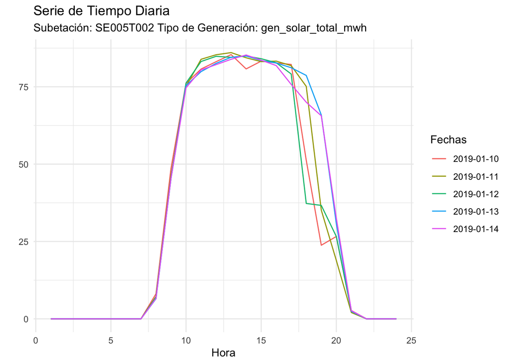

```r
plot_subestacion_variable("SE005T002",
                          "gen_solar_total_mwh",
                          c("2019-01-10", "2019-01-11", "2019-01-12",
                            "2019-01-13", "2019-01-14"))
```

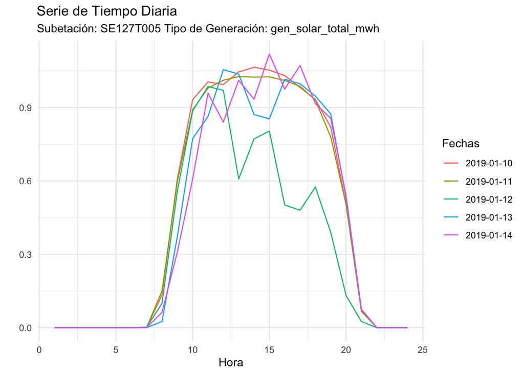

```r
plot_subestacion_variable("SE127T005",
                          "gen_solar_total_mwh",
                          c("2019-01-10", "2019-01-11", "2019-01-12",
                            "2019-01-13", "2019-01-14"))
```

- Grafica la curva de generación térmica, por hora, en la subestación SE020G213 para los días 14, 15, 16 y 17 de mayo de 2019. Haz lo mismo para la subestación SE106G216. Que podrías decir, en términos generales, sobre la generación térmica en esta subestación con respecto a este gráfico?

En este caso se puede ver que la subestación *“SE020G213”* tiene en promedio rendimientos cercanos a los 550 MWh durante el día salvo algunos días con caídas en la producción muy pronunciadas. En cambio, la subestación *“SE106G216”* tiene valores más cercanos a los 17 MWh pero tan solo una caída para el día 2019-05-15.

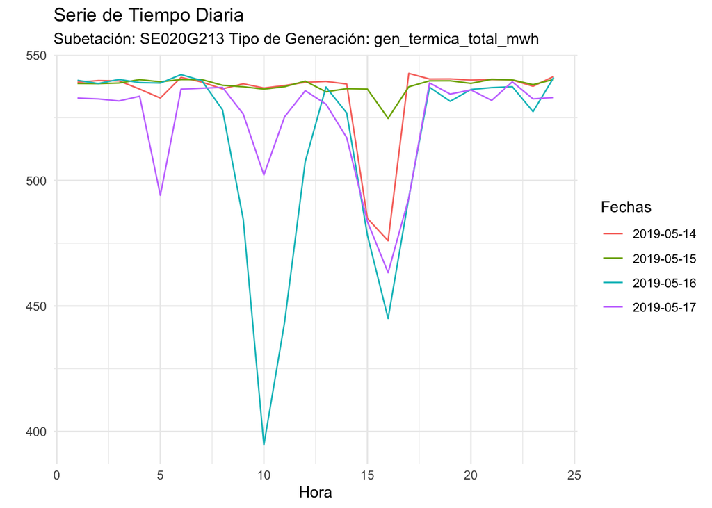

```r
plot_subestacion_variable("SE020G213",
                          "gen_termica_total_mwh",
                          c("2019-05-14", "2019-05-15", "2019-05-16",
                            "2019-05-17"))
```

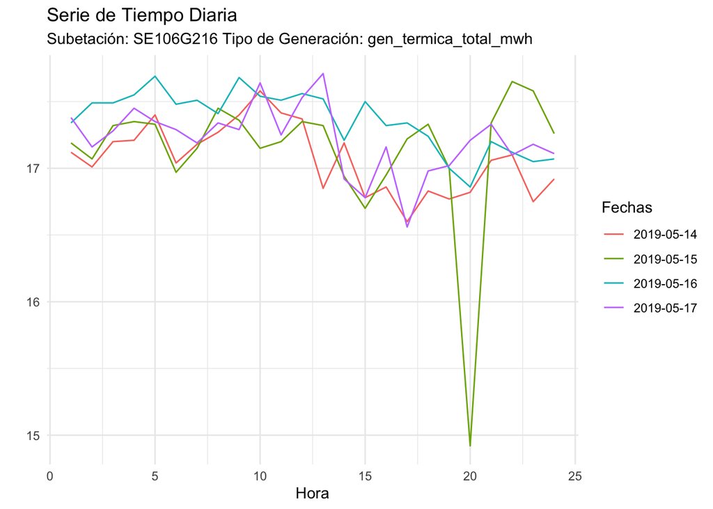

```r
plot_subestacion_variable("SE106G216",
                          "gen_termica_total_mwh",
                          c("2019-05-14", "2019-05-15", "2019-05-16",
                            "2019-05-17"))
```

## 5. Predicción de desviaciones del costo marginal: modelo 1

- Crea una variable target que sea igual a cero cuando la variable `cmg_desv_pct` esté en el rango [-15,15], e igual uno para cualquier otro caso. Hint: recuerda que existen valores infinitos.

```r
base_para_prediccion <- base_para_prediccion %>%
  filter(!is.infinite(cmg_desv_pct)) %>%  # Eliminando los valores infinitos
  mutate(target = case_when(abs(cmg_desv_pct) < 15 ~ 0,
                            TRUE ~ 1))
```

- Ahora crea los siguientes features:
- en_total_mwh: suma de las cinco series de generación.
- lags y estadísticas acumuladas (por ejemplo: promedio, varianza) de las variables que consideres relevantes.
- Entrena un modelo que prediga si existirá una desviación en la hora siguiente. Adecúa la variable target para hacer esto posible.
- ¿Cómo le va a tu modelo? ¿En qué métricas te basas y por qué?
- ¿Cuales son las variables más importantes que considera este modelo?

## 6. Predicción de desviaciones del costo marginal: modelo 2

Ahora imagina que te dicen que, en producción, te enviarán datos actualizados del sistema cada 12 horas. ¿Cuál debiese ser tu target a predecir en ese caso? Explica.

Entrena un nuevo modelo con ese target y evalúalo con una métrica que te parezca importante. ¿Cómo se compara con los resultados del modelo 1?

## 7. Merge con datos de clima: modelo 3

Haz un merge con los datos de clima (datos_clima.csv) y entrena nuevamente tu modelo 2.

```r
# Cargando los datasets
datos_clima <- read_csv("datos_clima.csv")
```

¿Cómo manejas el data leakage en este caso? ¿Cuánto mejora la capacidad predictiva del modelo? ¿Cuáles variables son las más importantes?

## 8. Reflexión

¿Por qué sería bueno utilizar un modelo como este para anticiparse a desvíos de precios de la energía? ¿Qué casos de uso te imaginas podrían beneficiarse teniendo acceso a un modelo como este?

Utilizar modelos para anticiparse a los desvíos deprecios de la energía son beneficiosos para todos los jugadores del mercado energético ya que les permite identificar los precios en los distintos tramos del proceso de generación. La predicción lo más ajustada posible permite hacer modelos económicos, de consumo y de generación que terminan redituando en un manejo más eficiente de las compañías y del Estado.

Por ejemplo, si una compañia generadora de energía puede predecir el costo marginal esperado en las próximas horas, puede ajustar su modelo económico de corto plazo (realizando erogaciones no esperadas por costos mayores o inversiones de corto plazo con el monto de dinero sobrante). A su vez, permite hacer un mejor uso de la red de electricidad a nivel país ya que dependiendo de la producción de energía en las próximas horas se pueden implementar medidas de importación o exportación para atender a los picos o valles de consumo o una redistribución de la energía hacia polos industriales o residenciales.